> **Status update (8 October 2026).** This summary covers notebooks 01–09 (runs 5/6). Later work changed some conclusions: **withdrawn** — perivascular T cells orienting 18S towards vessels (notebook 19: bleed from bright neighbours + outline geometry), a vimentin "ring" at lesion edges and vimentin-border containment (notebooks 16–17); **downgraded** — 18S texture as a severity marker (replicates only in glia/myeloid, notebook 13); **replicated** — white-matter neuropil loss (**narrowed 8 Oct:** only at the grey/white-matter border, notebook 20 §9), astrocyte RNA before vimentin protein, image-only models on unseen runs (notebook 13). **Withdrawn 8 Oct:** nuclear RNA retention in lesion oligodendrocytes (notebook 23). Current overall verdict: `report/BeyondBoundaries_verdict.pdf`; disease biology: `report/BeyondBoundaries_lesion_story.pdf`.

# Beyond Boundaries — what do the Xenium multimodal segmentation stains add to the transcriptome?

**Data.** Mouse EAE spinal cord (RRMAP2 runs 5 and 6): 18 annotated Xenium 5K sections, 25 animals (chronic and relapse-remitting EAE, CFA controls), 500,379 annotated cells. Four morphology channels besides transcripts: DAPI · ATP1A1/CD45/E-Cadherin (boundary) · 18S rRNA (interior RNA) · αSMA/Vimentin (interior protein).

This notebook only *collects* results (figures from `results/`, tables from CSVs); every number links to the notebook that computed it.

## Bottom line

[output not shown]

## 1. Features look right (notebook 01)

Mask areas equal Xenium's exactly; centroids within 0.28 µm; 0 truncated cells. Each stain has its own compartment — notably **ATP1A1 is higher *outside* cells** (neuropil).

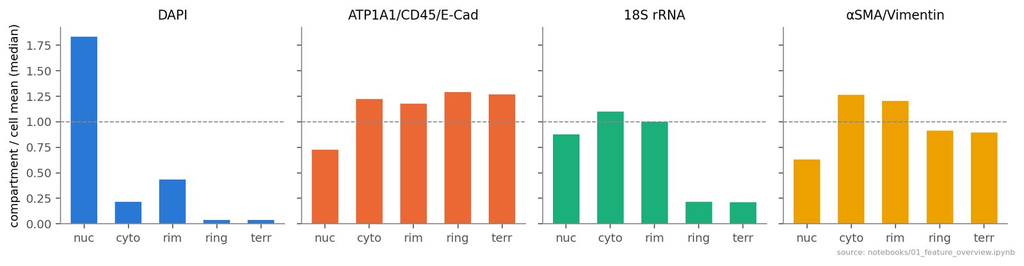

<sub>`results/01_features/compartment_profile.png`</sub>

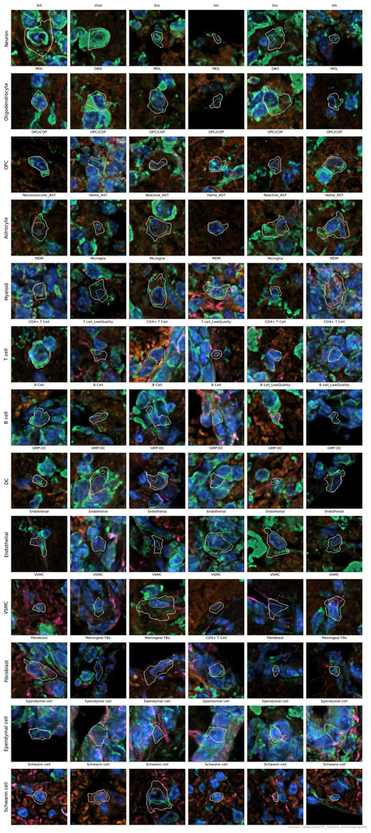

<sub>`results/01_features/cell_gallery.png`</sub>

## 2. Background and normalisation (notebook 02)

No broadband myelin autofluorescence (18S WM/GM 0.97). Final normalisation = local background subtraction, scaled per section by the p90 of physiological-niche cells. **Stain intensity tracks disease at piece level**: αSMA/Vim brighter (ρ = 0.45, p = 8e-4) and 18S dimmer (ρ = −0.42, p = 0.002) in physiological-niche cells of sicker animals.

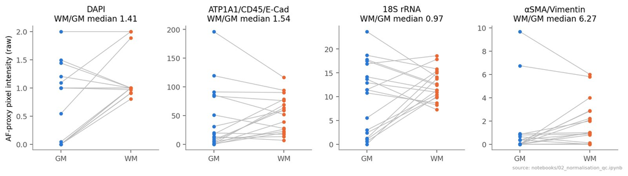

<sub>`results/02_normalisation_qc/af_wm_vs_gm.png`</sub>

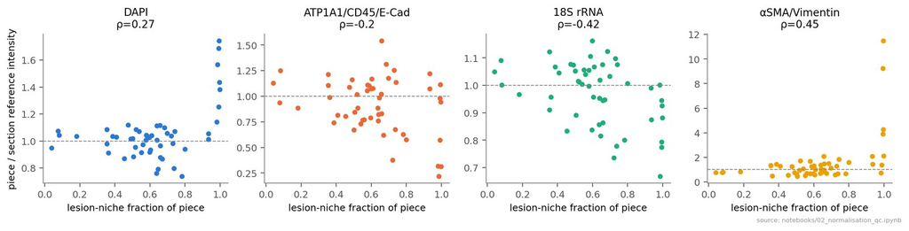

<sub>`results/02_normalisation_qc/piece_intensity_vs_lesion.png`</sub>

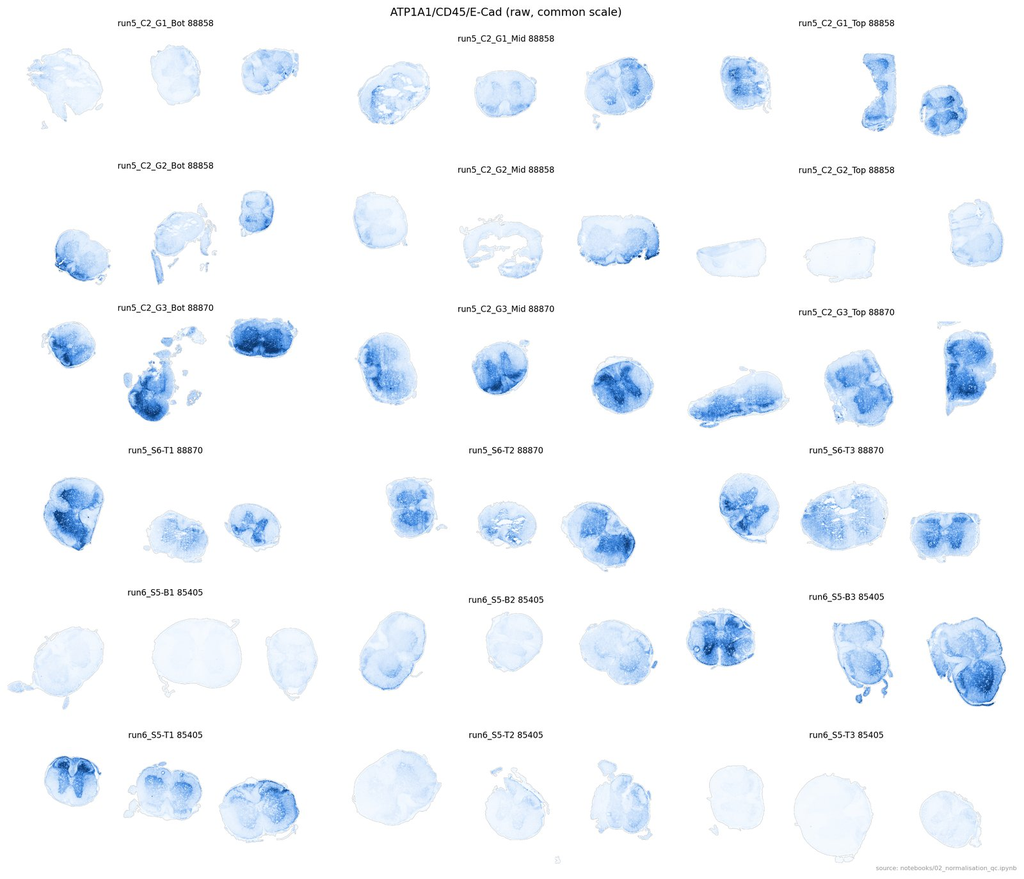

<sub>`results/02_normalisation_qc/spatial_bnd.png`</sub>

## 3. The stains recover known biology — except CD45 (notebook 03)

|  | test | feature | auroc | verdict |
| --- | --- | --- | --- | --- |
| 0 | E1 leukocyte CD45 rim | bnd_rim_over_ring | 0.477 | fails |
| 5 | E2 VSMC αSMA | smavim_cell_mean | 0.656 | holds |
| 10 | E3 leukocyte vimentin vs neuron/oligo | smavim_cell_mean | 0.734 | holds |
| 15 | E4 neuron/oligo low ch3 | smavim_cell_mean | 0.743 | holds |
| 20 | E5 ependymal vimentin | smavim_cell_mean | 0.859 | holds |
| 25 | E6 neuron 18S | r18s_cyto_mean | 0.780 | holds |

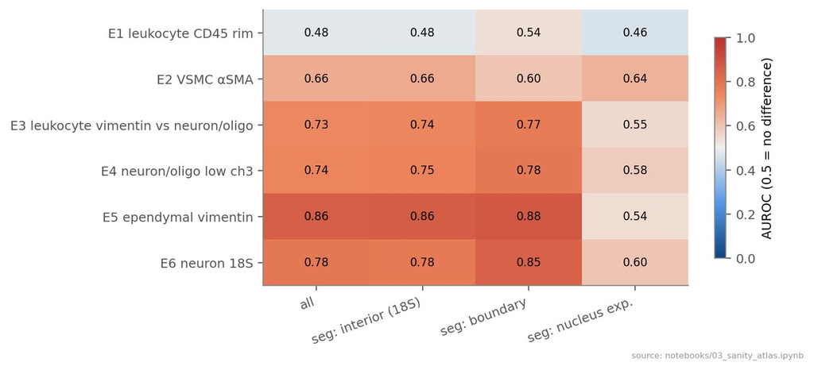

<sub>`results/03_sanity_atlas/expectation_tests.png`</sub>

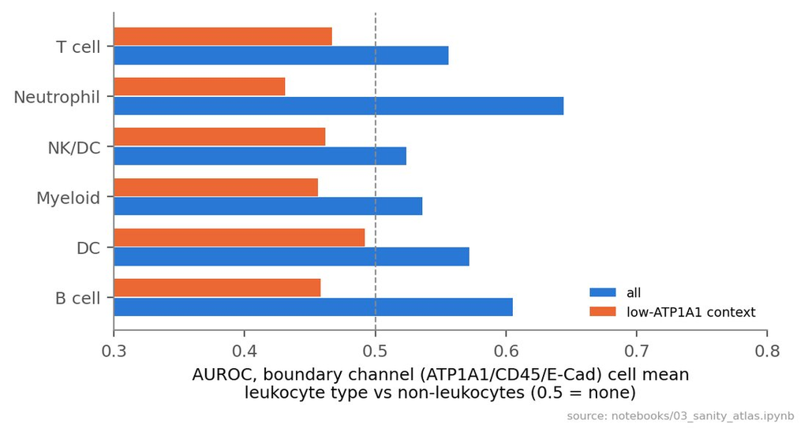

<sub>`results/03_sanity_atlas/E1_cd45_context.png`</sub>

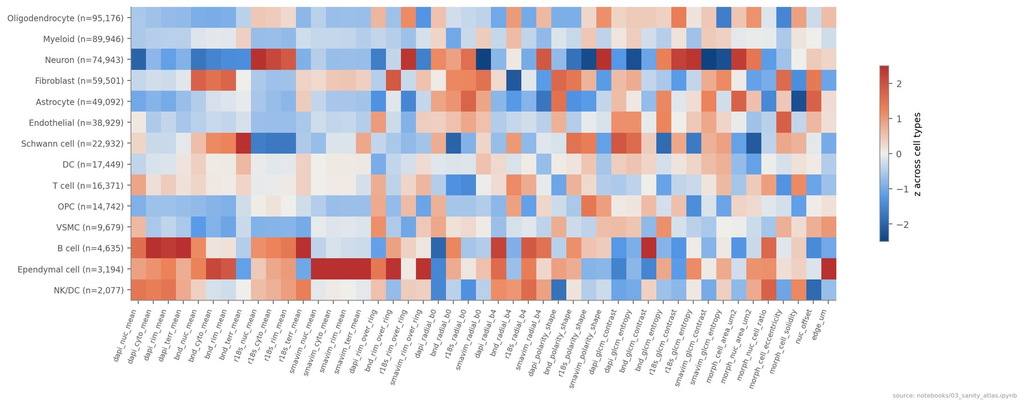

<sub>`results/03_sanity_atlas/atlas_celltype_heatmap.png`</sub>

Segmentation method shifts shape/distribution features for every cell type (the stain drew that edge), so all downstream analyses use 18S-segmented cells (96 %).

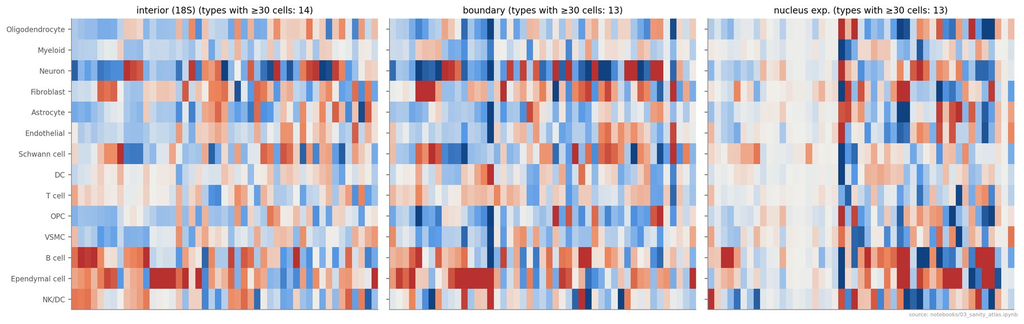

<sub>`results/03_sanity_atlas/atlas_by_segmethod.png`</sub>

## 4. The transcriptome explains ~15 % of the image; images predict transcriptional state (notebook 04)

| cell_type | R² covariates | R² covariates + transcriptome | ΔR² transcriptome |
| --- | --- | --- | --- |
| Schwann cell | 0.029 | 0.112 | 0.068 |
| Fibroblast | 0.042 | 0.123 | 0.068 |
| Neuron | 0.035 | 0.127 | 0.072 |
| Ependymal cell | 0.019 | 0.130 | 0.064 |
| NK/DC | 0.068 | 0.142 | 0.056 |
| VSMC | 0.037 | 0.148 | 0.091 |
| B cell | 0.053 | 0.148 | 0.067 |
| Oligodendrocyte | 0.048 | 0.152 | 0.090 |
| Endothelial | 0.063 | 0.156 | 0.075 |
| OPC | 0.048 | 0.160 | 0.067 |
| Myeloid | 0.055 | 0.163 | 0.105 |
| DC | 0.048 | 0.165 | 0.080 |
| T cell | 0.052 | 0.171 | 0.091 |
| Astrocyte | 0.081 | 0.177 | 0.071 |

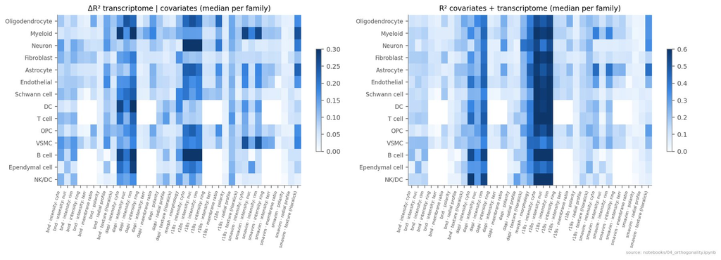

<sub>`results/04_orthogonality/r2_heatmaps.png`</sub>

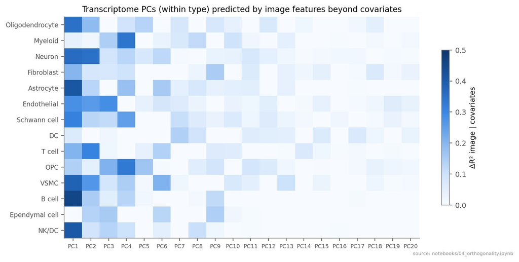

<sub>`results/04_orthogonality/reverse_pcs.png`</sub>

Genes best predicted by the images (beyond covariates), top 6 per cell type — reactive astrocyte genes, neurofilaments, oligodendrocyte maturation genes, and neighbour spill-over genes:

| cell_type | top genes predicted by image |
| --- | --- |
| Astrocyte | Slc6a11, C3, Snap25, Fgfr3, A2m, Aldoc |
| B cell | Jchain, Igkc, Sel1l, Gfap, Tent5c, Mzb1 |
| DC | Mbp, Neat1, Gfap, Snap25, Cst7, Lamp1 |
| Endothelial | Snap25, Eno2, Aldoc, Ckb, Sncb, Map2 |
| Ependymal cell | Mbp, Adamts20, Syne1, Plec, Ttll6, Rsph1 |
| Fibroblast | Gfap, Ptgds, Mbp, Neat1, Ctss, Crabp2 |
| Myeloid | Aldoc, Snap25, Map2, Ckb, Nefl, Mbp |
| NK/DC | Mbp, Gfap, Il2rb, Klrk1, Cd74, H2-D1 |
| Neuron | Meg3, Mbp, Nefm, Nefh, Map1b, Snap25 |
| OPC | Gfap, Snap25, Aldoc, Sncb, Eno2, Glra1 |
| Oligodendrocyte | Snap25, Gfap, Klk6, Eno2, Sncb, Ermn |
| Schwann cell | Pmp22, Cnp, Mbp, Cryab, Smtn, Cd9 |
| T cell | Mbp, Gfap, H2-D1, C3, Aldoc, Cd74 |
| VSMC | Vtn, Pdgfrb, Snap25, Mbp, Aldoc, Kcnj8 |

Images are redundant with the transcriptome for lesion-niche identity:

| cell_type | n | lesion_frac | AUROC tx | AUROC tx+img | AUROC img | ΔAUROC (img \| tx) |
| --- | --- | --- | --- | --- | --- | --- |
| Oligodendrocyte | 29895 | 0.605 | 0.928 | 0.929 | 0.650 | 0.001 |
| Myeloid | 29860 | 0.942 | 0.932 | 0.929 | 0.670 | -0.003 |
| Neuron | 29988 | 0.290 | 0.846 | 0.850 | 0.471 | 0.004 |
| Fibroblast | 29183 | 0.916 | 0.884 | 0.898 | 0.716 | 0.015 |
| Astrocyte | 29816 | 0.603 | 0.947 | 0.947 | 0.757 | -0.000 |
| Endothelial | 27406 | 0.645 | 0.937 | 0.938 | 0.747 | 0.001 |
| Schwann cell | 20610 | 0.367 | 0.936 | 0.940 | 0.769 | 0.004 |
| OPC | 14183 | 0.680 | 0.955 | 0.958 | 0.822 | 0.003 |
| VSMC | 8375 | 0.791 | 0.794 | 0.807 | 0.650 | 0.013 |
| Ependymal cell | 3005 | 0.062 | 0.948 | 0.946 | 0.816 | -0.002 |

## 5. What is the unexplained 85 %? (notebook 05)

Much of it is shared with neighbouring cells of *other* types (a local field) and that field does not follow lesions; the cell-specific remainder barely does either.

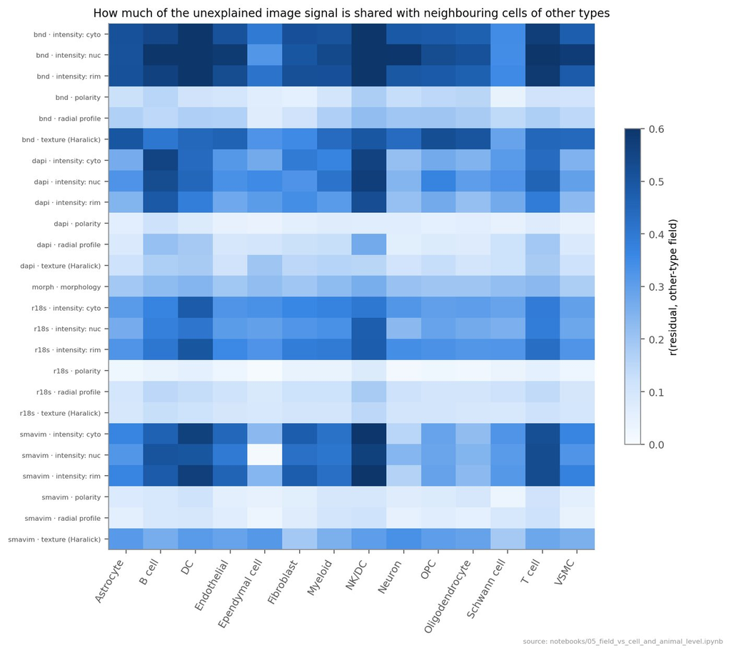

<sub>`results/05_field_and_animal/field_share_heatmap.png`</sub>

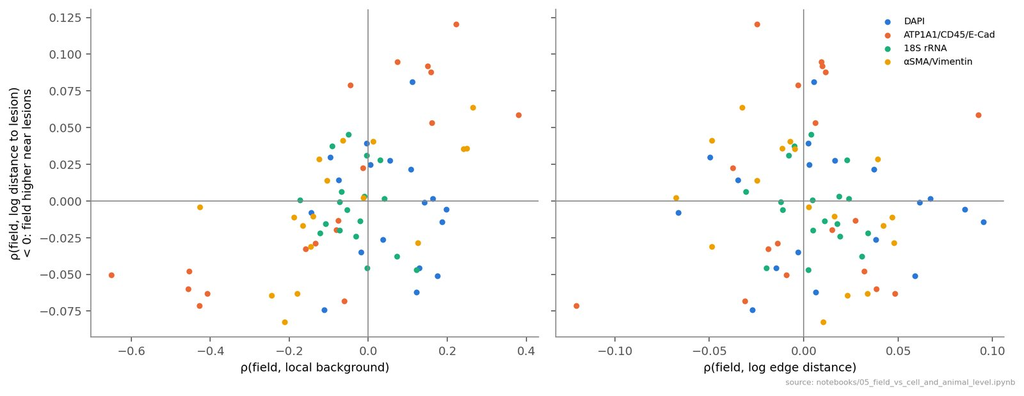

<sub>`results/05_field_and_animal/field_lesion_vs_technical.png`</sub>

| part | tests | q<0.05 |
| --- | --- | --- |
| cell-specific | 924 | 19 |
| field | 924 | 21 |
| full residual | 924 | 19 |

## 6. Per animal: images carry real but weaker disease information; 18S texture (later only partly replicated, notebook 13)

|  | R² | Spearman ρ | perm p (ρ) |
| --- | --- | --- | --- |
| section membership (batch) | -0.152 | -0.990 | NaN |
| transcriptome | 0.748 | 0.859 | 0.005 |
| image | 0.284 | 0.456 | 0.040 |
| transcriptome + image | 0.586 | 0.735 | NaN |

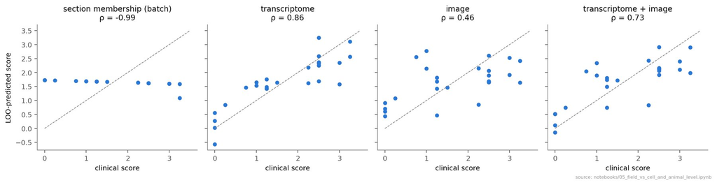

<sub>`results/05_field_and_animal/animal_score_prediction.png`</sub>

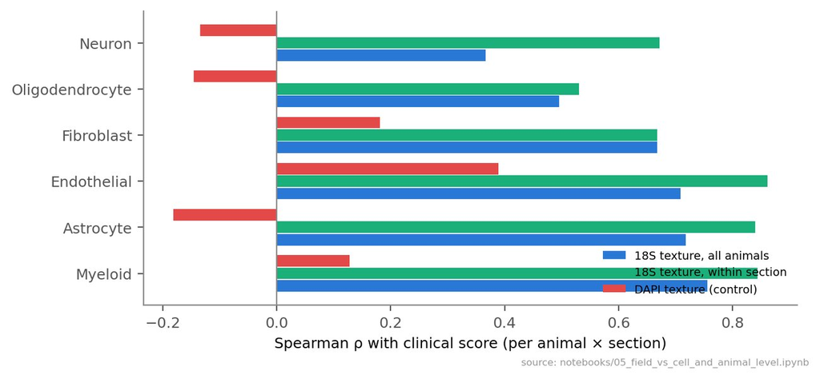

<sub>`results/05_field_and_animal/r18s_texture_within_section.png`</sub>

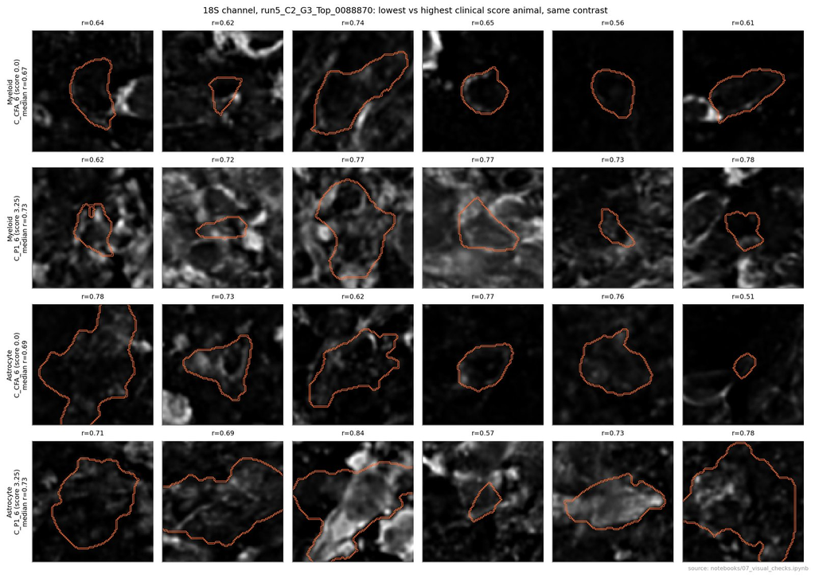

<sub>`results/07_visual_checks/r18s_texture_low_vs_high_score.png`</sub>

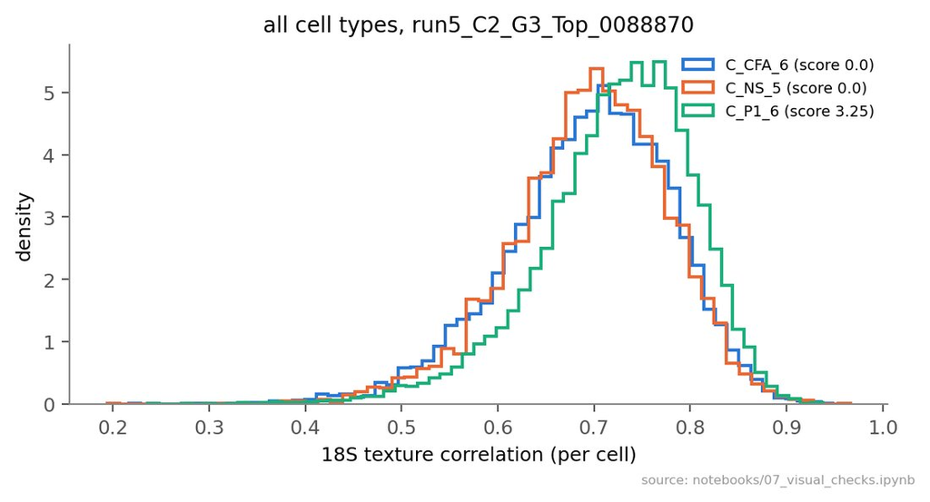

<sub>`results/07_visual_checks/r18s_texture_per_animal_hist.png`</sub>

Is it just crowding (bright 18S neighbours bleeding in)? Mostly not — the within-section link survives adjustment for neighbouring 18S, local density and cell size:

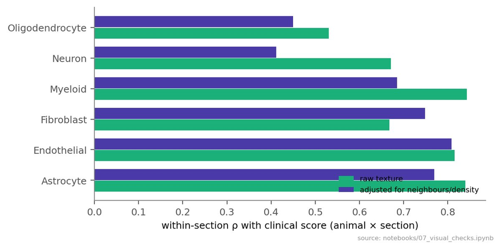

<sub>`results/07_visual_checks/r18s_texture_crowding_adjustment.png`</sub>

## 7. Targeted readouts (notebooks 06, 07)

### Astrocyte reactivity: vimentin protein vs RNA — transcription comes first

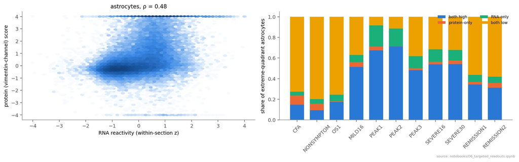

<sub>`results/06_targeted_readouts/astro_protein_vs_rna.png`</sub>

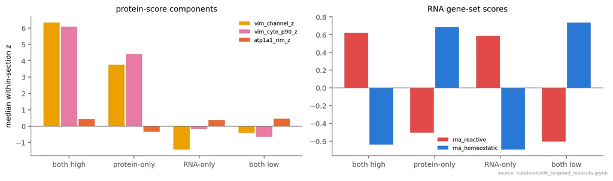

<sub>`results/06_targeted_readouts/astro_quadrant_components.png`</sub>

| quadrant | n | lesion_frac | WM_frac | lesion_dist_median | edge_um_median | area_median | transcripts_median | vim_channel_z | vim_cyto_p90_z | atp1a1_rim_z | rna_reactive_median | rna_homeostatic_median |
| --- | --- | --- | --- | --- | --- | --- | --- | --- | --- | --- | --- | --- |
| both high | 5853 | 0.950 | 0.856 | 0.000 | 101.389 | 88.190 | 1558.0 | 6.340 | 6.080 | 0.433 | 0.621 | -0.638 |
| protein-only | 401 | 0.284 | 0.147 | 29.779 | 297.379 | 74.011 | 1246.0 | 3.742 | 4.404 | -0.345 | -0.505 | 0.684 |
| RNA-only | 1312 | 0.949 | 0.772 | 0.000 | 127.557 | 68.141 | 1048.0 | -1.428 | -0.185 | 0.367 | 0.586 | -0.692 |
| both low | 4833 | 0.137 | 0.115 | 33.896 | 443.296 | 82.907 | 1363.0 | -0.411 | -0.660 | 0.454 | -0.604 | 0.736 |

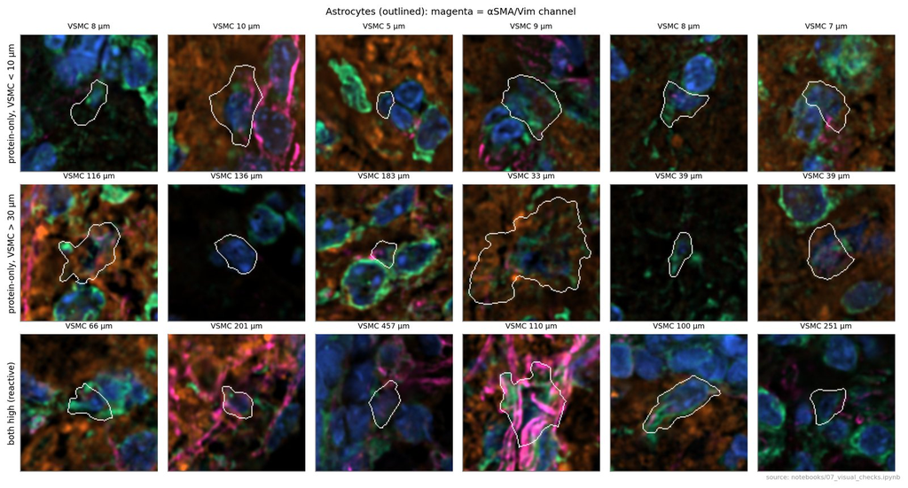

<sub>`results/07_visual_checks/astro_protein_only_vsmc_gallery.png`</sub>

### Leukocyte polarity — WITHDRAWN (notebook 19)

The 18S "towards vessels" signal below is bleed from 18S-bright neighbours plus outline geometry (a brightness-matched control removes it). The figures are kept for the record only.

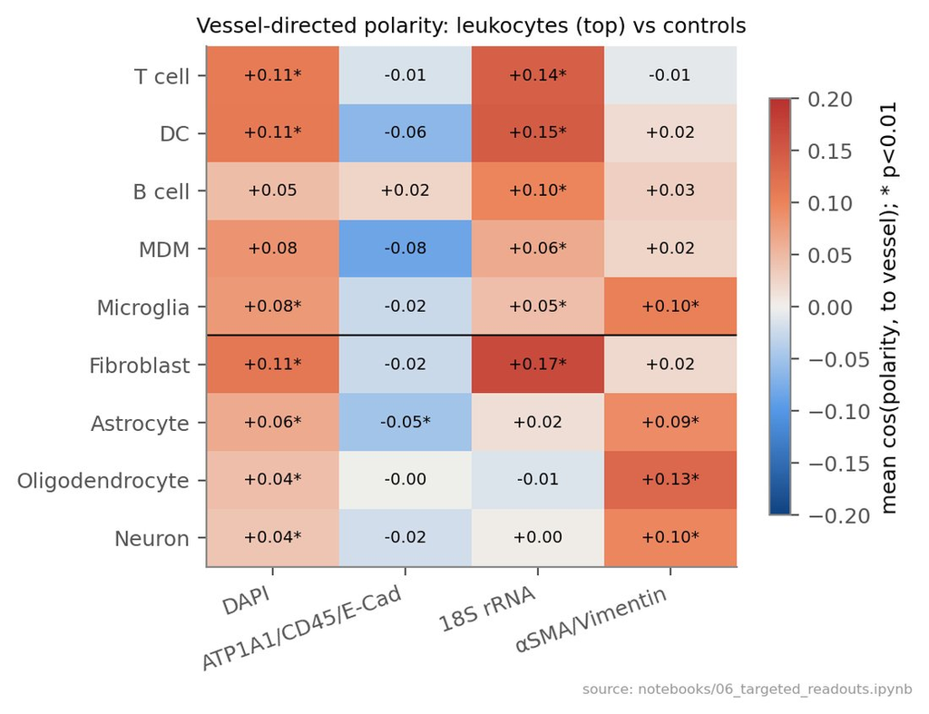

<sub>`results/06_targeted_readouts/polarity_vessel_direction.png`</sub>

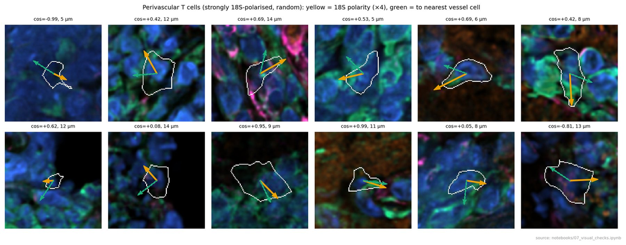

<sub>`results/07_visual_checks/tcell_perivascular_polarity.png`</sub>

### 18S rises in activated cells in lesions, beyond RNA content

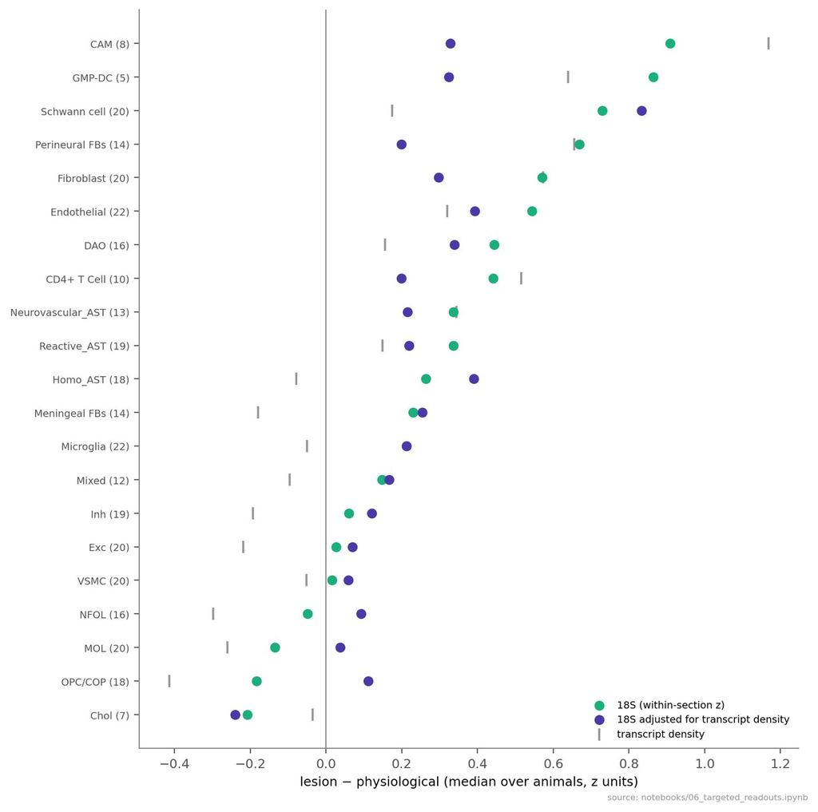

<sub>`results/06_targeted_readouts/r18s_lesion_by_type.png`</sub>

### Neuropil loss in white-matter lesions (within piece)

The −25 % shown here is superseded: matched for distance to grey matter the loss is ~15–20 % and only within ~75 µm of grey matter (notebook 20, section 9).

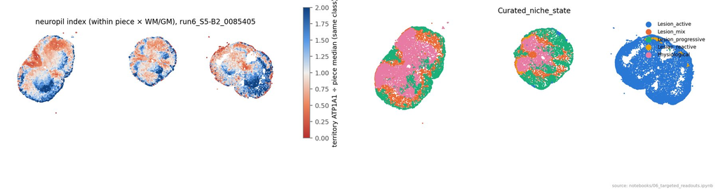

<sub>`results/06_targeted_readouts/neuropil_index_map.png`</sub>

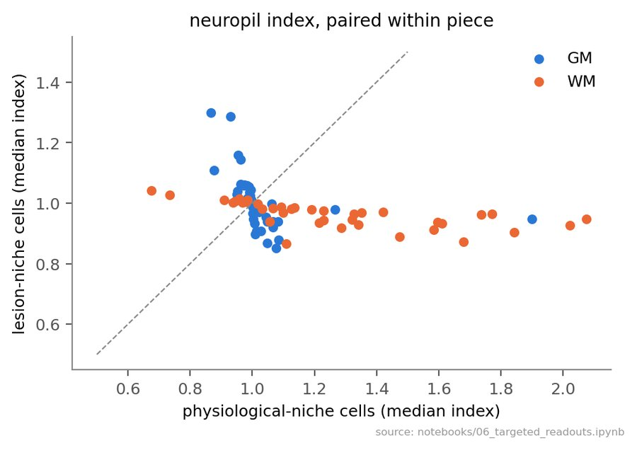

<sub>`results/06_targeted_readouts/neuropil_index_paired.png`</sub>

## 8. What the images can predict on their own (notebook 08)

Gradient-boosted trees on image features only, cross-validated by animal. Cell type at 46 % balanced accuracy (14 types, chance 7 %), errors within lineages; no single stain carries identity; subtypes recoverable.

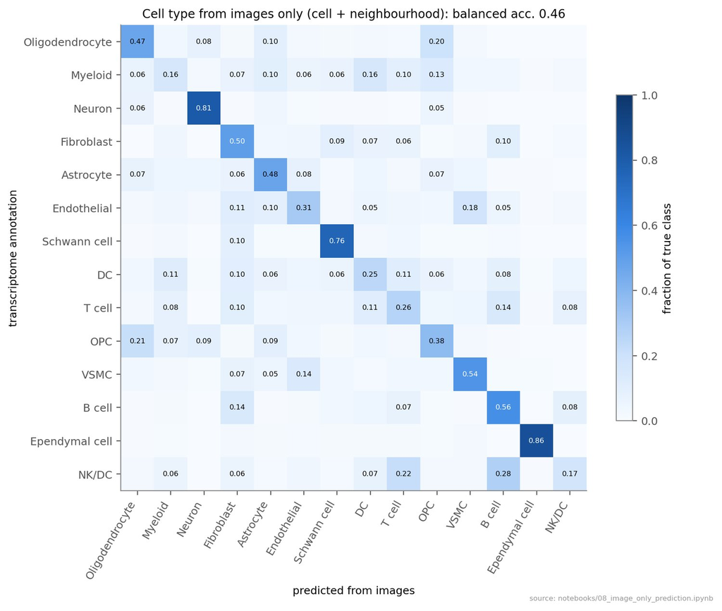

<sub>`results/08_image_only_prediction/L1_confusion.png`</sub>

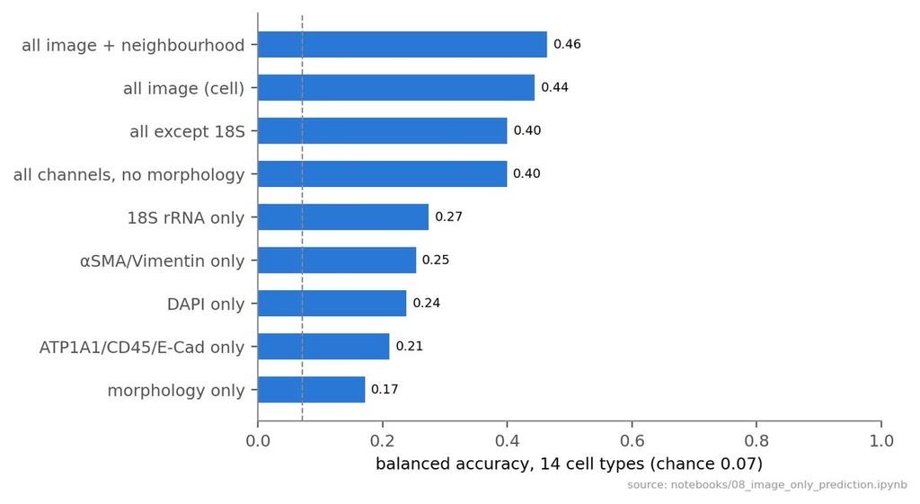

<sub>`results/08_image_only_prediction/L1_feature_set_ablation.png`</sub>

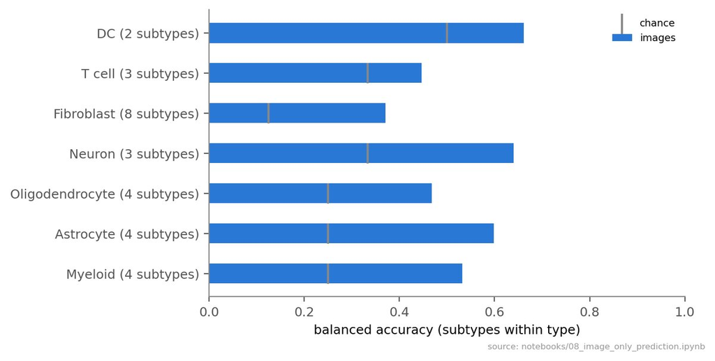

<sub>`results/08_image_only_prediction/L2_within_type.png`</sub>

Anatomy and lesion state — images add to the transcriptome for anatomy (0.68 → 0.73):

|  | task | inputs | balanced acc. | chance (balanced) |
| --- | --- | --- | --- | --- |
| 0 | anatomical region | images (cell + neighbourhood) | 0.625 | 0.100 |
| 1 | anatomical region | transcriptome cell-type composition | 0.683 | 0.100 |
| 2 | anatomical region | both | 0.730 | 0.100 |
| 3 | lesion state | images (cell + neighbourhood) | 0.535 | 0.143 |
| 4 | lesion state | transcriptome cell-type composition | 0.648 | 0.143 |
| 5 | lesion state | both | 0.665 | 0.143 |

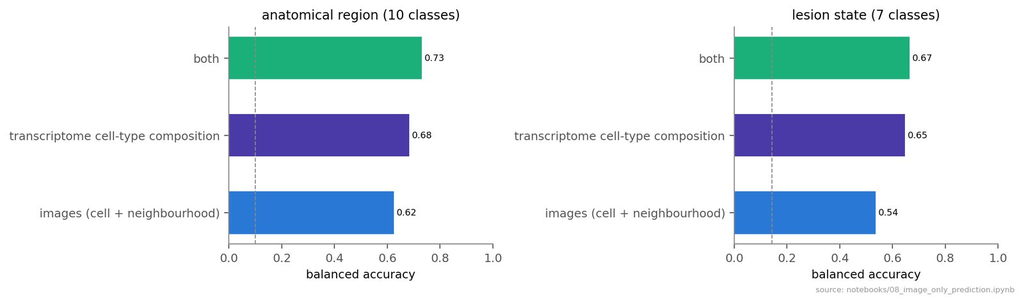